# Progressive Machine Learning Examples

Anton Antonov, [MathematicaVsR at GitHub](https://github.com/antononcube/MathematicaVsR)

15 April, 2018

*(This R notebook is part of the [MathematicaVsR at GitHub](https://github.com/antononcube/MathematicaVsR) project ProgressiveMachineLearning.)*

# Introduction

In this R notebook we show how to do progressive machine learning using Tries with Frequencies, [AAp2, AA1]. (I plan in the near future to extend the notebook with an example using the Sparse Matrix Recommender framework [AAp4].)

## What is Progressive Machine Learning?

[Progressive learning](https://en.wikipedia.org/wiki/Online_machine_learning#Progressive_learning) is a type of [Online machine learning](https://en.wikipedia.org/wiki/Online_machine_learning). For more details see [[Wk1](https://en.wikipedia.org/wiki/Online_machine_learning)]. Progressive learning is defined as follows.

- Assume that the data is sequentially available.
  - Meaning, at a given time only part of the data is available, and after a certain time interval new data is obtained.
  - In view of classification, it is assumed that at a given time not all class labels are presented in the data already obtained.
  - Let us call this a data stream.
- Consider (the making of) a machine learning algorithm that updates its model continuously or sequentially in time over a given data stream.
  - Let us call such an algorithm a Progressive Learning Algorithm (PLA).

In comparison, the typical (classical) machine learning algorithms assume that representative training data is available and after training that data is no longer needed to make predictions. Progressive machine learning has more general assumptions about the data and its problem formulation is closer to how humans learn to classify objects.

Below we are going to see the application of a Trie with Frequencies (TF) based classifier as PLAs.

### Definition from Wikipedia

Here is the definition of Progressive learning from [Wk1]:

Progressive learning is an effective learning model which is demonstrated by the human learning process. It is the process of learning continuously from direct experience. Progressive learning technique (PLT) in machine learning can learn new classes/labels dynamically on the run. Though online learning can learn new samples of data that arrive sequentially, they cannot learn new classes of data being introduced to the model. The learning paradigm of progressive learning, is independent of the number of class constraints and it can learn new classes while still retaining the knowledge of previous classes. Whenever a new class (non-native to the knowledge learnt thus far) is encountered, the classifier gets remodeled automatically and the parameters are calculated in such a way that it retains the knowledge learnt thus far. This technique is suitable for real-world applications where the number of classes is often unknown and online learning from real-time data is required.

# Data

In this section we obtain and summarize the well known “Titanic” data-set.

(The data for this project has been prepared with the Mathematica (Wolfram Language) package [AAp1].)

```r
dfTitanic <- read.csv("https://raw.githubusercontent.com/antononcube/MathematicaVsR/master/Data/MathematicaVsR-Data-Titantic.csv", stringsAsFactors = F)
dim(dfTitanic)
```

```
[1] 1309    5
```

```r
head(dfTitanic)
```

|  | id | passengerClass | passengerAge | passengerSex | passengerSurvival |
| --- | --- | --- | --- | --- | --- |
| 1 | 1 | 1st | 30 | female | survived |
| 2 | 2 | 1st | 0 | male | survived |
| 3 | 3 | 1st | 0 | female | died |
| 4 | 4 | 1st | 30 | male | died |
| 5 | 5 | 1st | 20 | female | died |
| 6 | 6 | 1st | 50 | male | survived |

```r
summary(as.data.frame(unclass(dfTitanic)))
```

```
       id       passengerClass  passengerAge   passengerSex passengerSurvival
 Min.   :   1   1st:323        Min.   :-1.00   female:466   died    :809
 1st Qu.: 328   2nd:277        1st Qu.:10.00   male  :843   survived:500
 Median : 655   3rd:709        Median :20.00
 Mean   : 655                  Mean   :23.55
 3rd Qu.: 982                  3rd Qu.:40.00
 Max.   :1309                  Max.   :80.00
```

Here is the summary of the long form:

```r
summary(setNames(melt(as.matrix(dfTitanic)),c("RowID", "Variable", "Value")), maxsum = 12)
```

```
     RowID                   Variable         Value
 Min.   :   1   id               :1309   male    : 843
 1st Qu.: 328   passengerClass   :1309   died    : 809
 Median : 655   passengerAge     :1309   3rd     : 709
 Mean   : 655   passengerSex     :1309   survived: 500
 3rd Qu.: 982   passengerSurvival:1309   female  : 466
 Max.   :1309                            20      : 334
                                         1st     : 323
                                         2nd     : 277
                                         -1      : 263
                                         30      : 258
                                         40      : 190
                                         (Other) :1573
```

# General progressive learning simulation loop

In this notebook we simulate the data stream given to a Progressive learning algorithm.

We are going to use the following steps:

1. Get a data-set.
2. Split data-set into training and test data-sets.
3. Split training data-set into disjoint data-sets.
4. Make an initial trie `t1`.
5. Get a new data subset.
6. Make a new trie `t2` with the new data-set.
7. Merge trie `t1` with trie `t2`.
8. Classify the test data-set using `t1`.
9. Output sizes of `t1` and classification success rates.
10. Accumulate ROC statistics.
11. Are there more training data subsets?
    - If “Yes” go to step 5.
    - If “No” go to step 12.
12. Display ROC plots.

The flow chart below follows the sequence of steps given above.

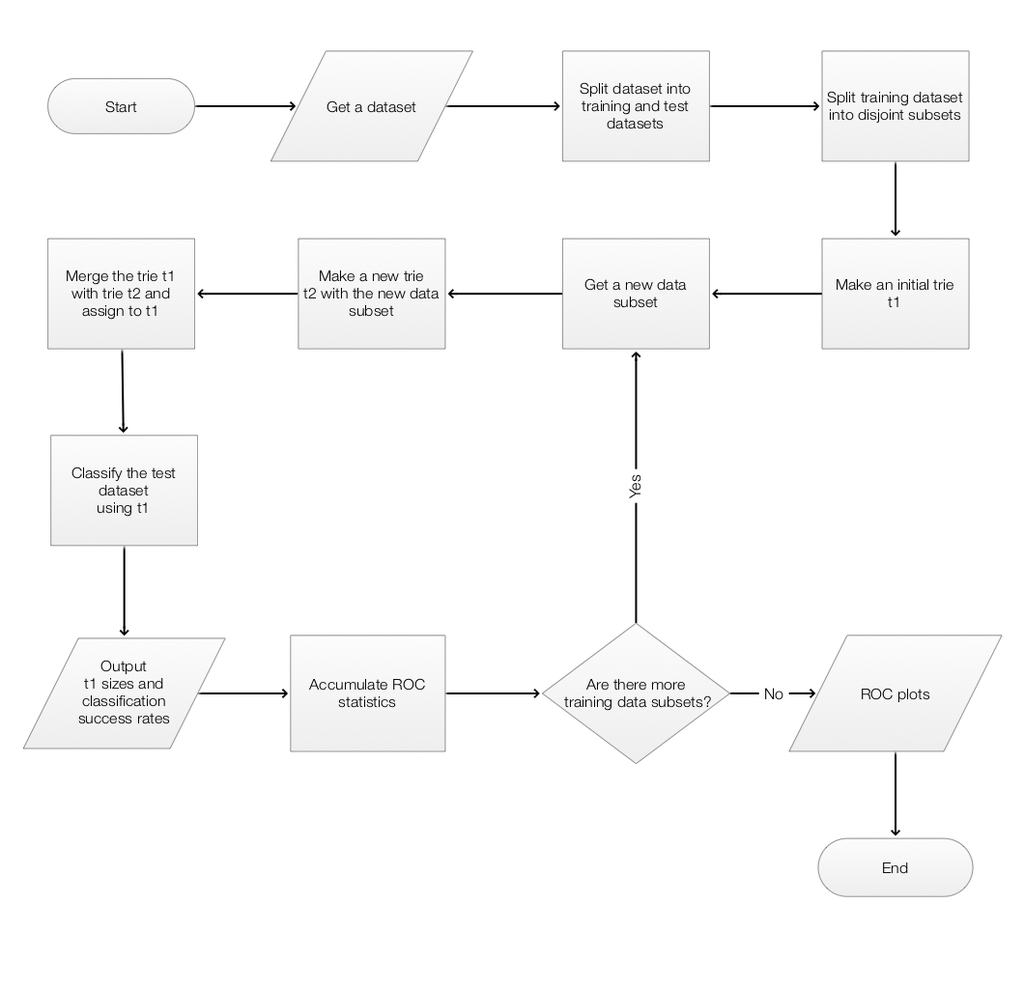

# Data sorting

We are going to sort the training data and the training and the sample indices in order to exaggerate the progressive learning effect.

With the data stream based on sorted data in the initial progressive learning stages not all class labels and variable correlations would be seen.

```r
dfTitanic <- dfTitanic[do.call(order,dfTitanic),]
```

# Progressive learning with Tries with frequencies

Here we set the classification label column:

```r
labelColumnName <- "passengerSurvival"
```

Here we determine the class label to focus on:

```r
focusLabel <- count( dfTitanic[[labelColumnName]] )
focusLabel <- as.character(focusLabel[which.min(focusLabel$freq),1])
focusLabel
```

```
[1] "survived"
```

## Data separation and preparation

Here we separate the indices of the data.

```r
set.seed(2344)
trainingInds <- sample( 1:nrow(dfTitanic), round(0.75*nrow(dfTitanic)))
testInds <- setdiff(1:nrow(dfTitanic), trainingInds)
```

In general, when using a trie for classification that process might be sensitive of the order the variables, especially for data with smaller number of records and/or large number of variables. That is why here we select a permutation. (And make sure that the selected class label variable is the last index in the permutation.)

```r
perm <- c(1,2,3,4,5)
```

Here we make the data easier for using with Tries. Note that we drop the “id” column.

```r
trainingData <- dlply( dfTitanic[sort(trainingInds), perm], "id", function(x) { as.character(x[1,-1]) } )
testData <- dlply( dfTitanic[sort(testInds), perm], "id", function(x) { as.character(x[1,-1]) } )
```

## Basic trie creation and classisification

```r
tr <- TrieCreate( trainingData )
ptr <- TrieNodeProbabilities(tr)
```

Classification of a single test record:

```r
record <- testData[[120]]
TrieClassify( ptr, record[grep(labelColumnName, colnames(dfTitanic), invert = TRUE)], type = "Probabilities" )
```

```
survived
       1
```

Here we do the classification for all test records:

```r
records <- llply( testData, function(x) x[-length(x)])
clRes <- laply( records, function(x) TrieClassify(ptr, x, default = "NA"))
```

Here we cross tabulate the actual and predicted class labels:

```r
ctMat <- xtabs( ~ Actual + Predicted, data.frame( Actual = dfTitanic[testInds, labelColumnName], Predicted = clRes), addNA = T )
ctMat
```

```
          Predicted
Actual     died survived
  died      172       30
  survived   44       81
```

Success rates:

```r
ctMat / rowSums(ctMat)
```

```
          Predicted
Actual          died  survived
  died     0.8514851 0.1485149
  survived 0.3520000 0.6480000
```

## The Progressive learning loop

Here is data frame that is used to split the training data:

```r
bs <- unique(c(seq(0,300,100), seq(300,length(trainingInds),200),length(trainingData)))
splitRanges <- data.frame( Begin = bs[-length(bs)]+1, End = bs[-1] )
splitRanges
```

| Begin | End |
| --- | --- |
| 1 | 100 |
| 101 | 200 |
| 201 | 300 |
| 301 | 500 |
| 501 | 700 |
| 701 | 900 |
| 901 | 982 |

Below is given the Progressive learning loop. The comments mark the individual steps.

```r
# Make initial trie
tr <- TrieCreate( trainingData[ splitRanges$Begin[[1]]:splitRanges$End[[1]] ] )
# The main loop
for( i in 2:nrow(splitRanges) ) {
  # Make trie with new dara
  tr2 <- TrieCreate( trainingData[ splitRanges$Begin[[i]]:splitRanges$End[[i]] ] )

  # Merge the current trie with the new trie
  tr <- TrieMerge( tr, tr2 )

  # Turn frequencies into probabilities and assign class attribute
  ptr <- TrieNodeProbabilities( tr )
  class(ptr) <- "TrieWithFrequencies"

  # Turn test data into a data frame
  df <- setNames(do.call(rbind.data.frame, testData), NULL)
  fInds <- sapply(df, is.factor)
  df[fInds] <- lapply(df[fInds], as.character)

  # Classify
  clRes <- predict( ptr, df[, -ncol(df) ] )

  # Cross tabulate actuabl and predicted labels
  ctMat <- xtabs( ~ Actual + Predicted, data.frame( Actual = df[, ncol(df)], Predicted = clRes), addNA = T )

  # Proclaim
  cat("\n\n\t\ti = ", i, "\n")
  print(TrieNodeCounts(ptr)); cat("\n")
  print(ctMat); cat("\n")
  print(ctMat / rowSums(ctMat))

  # Accumulate probabilities for ROC plots
  clRes <- predict( ptr, df[,1:(ncol(df)-1)], type = "Probabilities", default = "NA" )
  if("NA" %in% colnames(clRes) ) colRes <- colRes[, grep("NA", colnames(clRes), invert = T)]
  clROC <- ROCValues( classResMat = clRes, testLabels = df[,ncol(df)], range = seq(0,1,0.05) )
  clROC <- cbind( clROC, Model = as.character(i) )
  if (i == 2) { rocDF <- clROC }
  else { rocDF <- rbind(rocDF, clROC) }
}
```

```
        i =  2
   Total Internal   Leaves
      59       31       28

          Predicted
Actual     died survived
  died       28      174
  survived   18      107

          Predicted
Actual          died  survived
  died     0.1386139 0.8613861
  survived 0.1440000 0.8560000


        i =  3
   Total Internal   Leaves
     101       54       47

          Predicted
Actual     died survived
  died       58      144
  survived   20      105

          Predicted
Actual          died  survived
  died     0.2871287 0.7128713
  survived 0.1600000 0.8400000


        i =  4
   Total Internal   Leaves
     145       73       72

          Predicted
Actual     died survived
  died      178       24
  survived   54       71

          Predicted
```

[output cut: 33 more lines]

```


        i =  7
   Total Internal   Leaves
     169       83       86

          Predicted
Actual     died survived
  died      171       31
  survived   44       81

          Predicted
Actual          died  survived
  died     0.8465347 0.1534653
  survived 0.3520000 0.6480000
```

Here we plot the ROC curves using package [AAp3]:

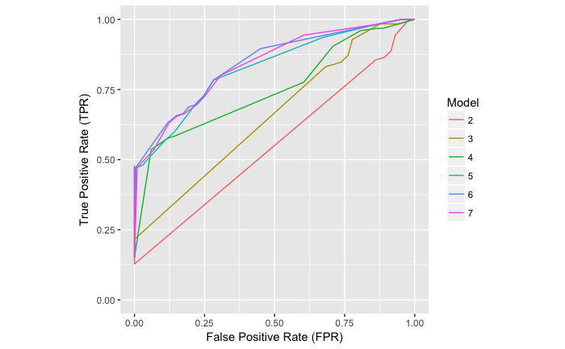

```r
ROCPlot( rocDF = rocDF, point.text = FALSE ) + theme( aspect.ratio = 1 )
```

# Using an Item-item recommender system

## Data preparation

```r
labelColumnName = "passengerSurvival"
```

```r
trainingData <- dfTitanic[trainingInds,]
testData <- dfTitanic[testInds,]
```

## The Progressive learning loop

Here is data frame that is used to split the training data:

```r
bs <- unique(c(seq(0,300,100), seq(300,length(trainingInds),200), nrow(trainingData)))
splitRanges <- data.frame( Begin = bs[-length(bs)]+1, End = bs[-1] )
splitRanges
```

| Begin | End |
| --- | --- |
| 1 | 100 |
| 101 | 200 |
| 201 | 300 |
| 301 | 500 |
| 501 | 700 |
| 701 | 900 |
| 901 | 982 |

Below is given the Progressive learning loop. The comments mark the individual steps.

```r
# Make initial SMR object
smr <- SMRCreate( trainingData[ splitRanges$Begin[[1]]:splitRanges$End[[1]], ],
                  tagTypes = setdiff( colnames(trainingData), "id" ),
                  itemColumnName = "id" )
# The main loop
for( i in 2:nrow(splitRanges) ) {
  # Make SMR object with new dara
  smr2 <- SMRCreate( trainingData[ splitRanges$Begin[[i]]:splitRanges$End[[i]], ],
                     tagTypes = setdiff( colnames(trainingData), "id" ),
                     itemColumnName = "id" )

  # Merge the current SMR object with the new SMR object
  smr <- SMRRowBind( smr1 = smr, smr2 = smr2 )

  # Classify
  clRes <- predict( smr,
                    testData[, grep( labelColumnName, colnames(testData), invert = T )],
                    nTopNNs = 40, type = "decision", tagType = labelColumnName )

  # Cross tabulate actual and predicted labels
  ctMat <- xtabs( ~ Actual + Predicted, data.frame( Actual = testData[, labelColumnName], Predicted = clRes), addNA = T )

  # Proclaim
  cat("\n\n\t\ti = ", i, "\n")
  print(dim(smr$M01)); cat("\n")
  print(ctMat); cat("\n")
  print(ctMat / rowSums(ctMat))

  # Accumulate scores for ROC plots
  clRes <- predict( smr,
                    testData[, grep( labelColumnName, colnames(testData), invert = T )],
                    nTopNNs = 40, type = "raw", tagType = labelColumnName )
  clROC <- ROCValues( classResMat = clRes, testLabels = testData[, labelColumnName], range = seq(0,1,0.05) )
  clROC <- cbind( clROC, Model = as.character(i) )
  if (i == 2) { rocDF <- clROC }
  else { rocDF <- rbind(rocDF, clROC) }
}
```

```
        i =  2
[1] 200  15

          Predicted
Actual     died survived
  died      182       20
  survived   53       72

          Predicted
Actual          died  survived
  died     0.9009901 0.0990099
  survived 0.4240000 0.5760000


        i =  3
[1] 300  15

          Predicted
Actual     died survived
  died      195        7
  survived   66       59

          Predicted
Actual           died   survived
  died     0.96534653 0.03465347
  survived 0.52800000 0.47200000


        i =  4
[1] 500  16

          Predicted
Actual     died survived
  died      191       11
  survived   55       70

          Predicted
Actual           died   survived
  died     0.94554455 0.05445545
  survived 0.44000000 0.56000000
```

[output cut: 27 more lines]

```
  survived 0.3760000 0.6240000


        i =  7
[1] 982  17

          Predicted
Actual     died survived
  died      177       25
  survived   47       78

          Predicted
Actual          died  survived
  died     0.8762376 0.1237624
  survived 0.3760000 0.6240000
```

Here we plot the ROC curves using package [AAp3]:

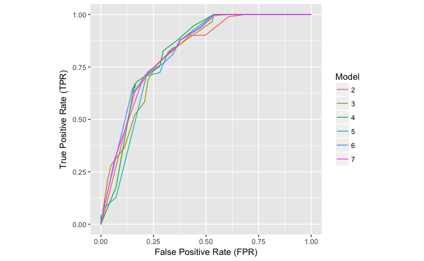

```r
ROCPlot( rocDF = rocDF, point.text = FALSE ) + theme( aspect.ratio = 1 )
```

# References

## Packages

[AAp1] Anton Antonov, Obtain and transform Mathematica machine learning data-sets, GetMachineLearningDataset.m, (2018), [MathematicaVsR at GitHub](https://github.com/antononcube/MathematicaVsR).

[AAp2] Anton Antonov, Tries with frequencies R package, TriesWithFrequencies.R, (2014), [MathematicaForPrediction at GitHub](https://github.com/antononcube/MathematicaForPrediction).

[AAp3] Anton Antonov, Variable importance determination by classifiers implementation in R, VariableImportanceByClassifiers.R, (2017), [MathematicaForPrediction at GitHub](https://github.com/antononcube/MathematicaForPrediction).

[AAp4] Anton Antonov, “Sparse matrix recommender framework in R”, SparseMatrixRecommender.R, (2014), [MathematicaForPrediction at GitHub](https://github.com/antononcube/MathematicaForPrediction).

## Articles

[Wk1] Wikipedia entry, [Online machine learning](https://en.wikipedia.org/wiki/Online_machine_learning).

[AA1] Anton Antonov, [“Tries with frequencies in Java”](https://mathematicaforprediction.wordpress.com/2017/01/31/tries-with-frequencies-in-java/), (2017), [MathematicaForPrediction at WordPress](https://mathematicaforprediction.wordpress.com).